# Selling SPY Weeklys: 2014 - 2018

No-Trade Signals

Pritam Dalal

February 7, 2019

The purpose of this analysis is to compare the performance impact of two different no-trade signals:

1. `simple sit-out` - sit out if there was a loss of 200% of premium sold for the previous expiration.
2. `volatiltiy premium forecasts` - we calculate a volatility premium forecast by calculating a GARCH(1,1) forecast for realized volatility. We then calculate the z-score of that volatility forecast. If the z-score is less that -1.5, we don’t trade.

These mechanisms are applied to the `base case` of strangle selling with 10% threshold delta-hedging, and 300% loss-trigger position unwinds.

#### Overall Peformance

The `forecast` mechanism hurts performance slightly, while the `sit-out` mechanism significantly enhances performance.

| signal | total_pnl | stdev_pnl | sharpe |
| --- | --- | --- | --- |
| base | 16.20 | 2.59 | 1.25 |
| forecast | 15.35 | 2.57 | 1.19 |
| sitout | 18.72 | 2.19 | 1.71 |

#### Visualizing Cumulative Performance

By observing the cumulative performance graph it’s easy to see that most of the out-performance of the `sit-out` signal comes from avoding an extremely costly expiration in early 2018.

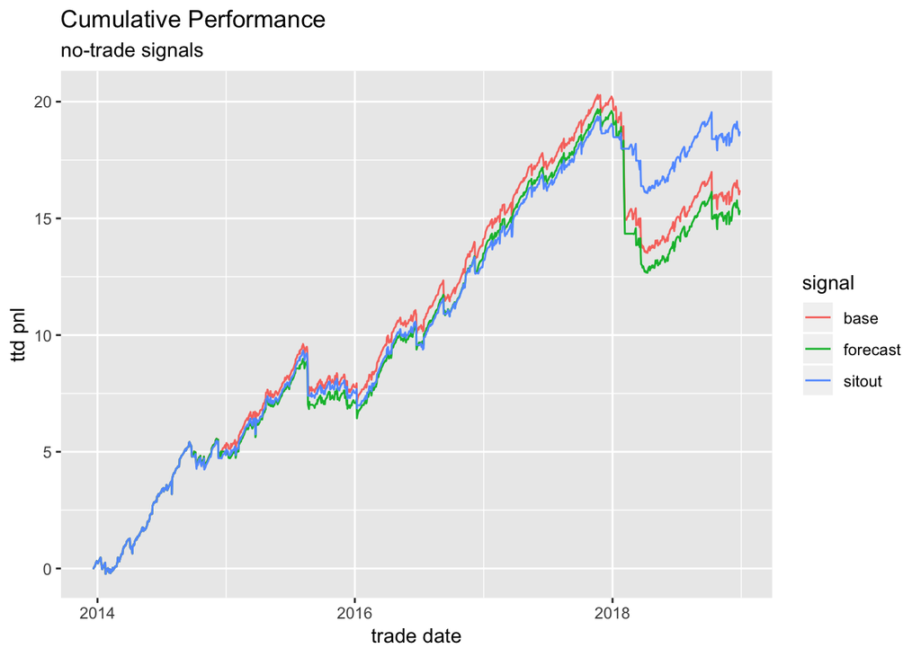

Both signals are a slight drag on performance in the good times, which should be expected. By employing a no-trade signals, you will no doubt lose out on some false-positive winners. But the question is whether that inevitable cost will come with the benefit of avoiding some painful trades. The answer is yes for `sit-out` but not for `forecast`.

#### Performance by Year

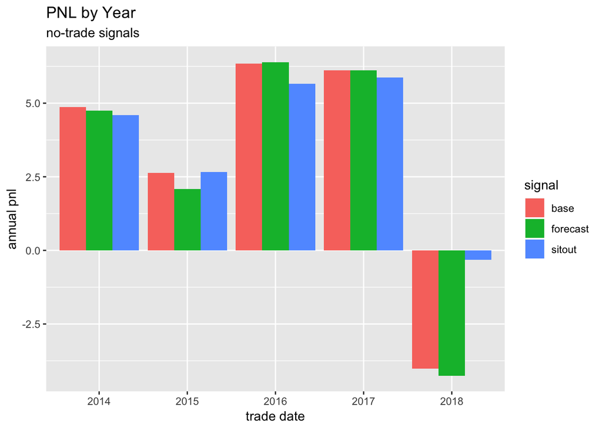

[figure not shown]

#### Conclusion & Recommendation

Selling options is good until it isn’t. The key to a successful option selling is proper risk management. The simple strategy of sitting out a week after a significant loss makes strong intuitive sense, and its success comes as no suprise given the well known phenomenon of realized volatility clustering.

Now it’s true that the success of the `sit-out` signal is largely based on avoiding certain trades in 2018, but it really doesn’t hurt much in other years (the good times).

When the markets are experience significant turmoil, it’s not a bad idea to sit out for a bit. There will be plenty of time to make money again when turbulence subsides.

My next analysis will assume the employment of `sit-out` no-trade signal.